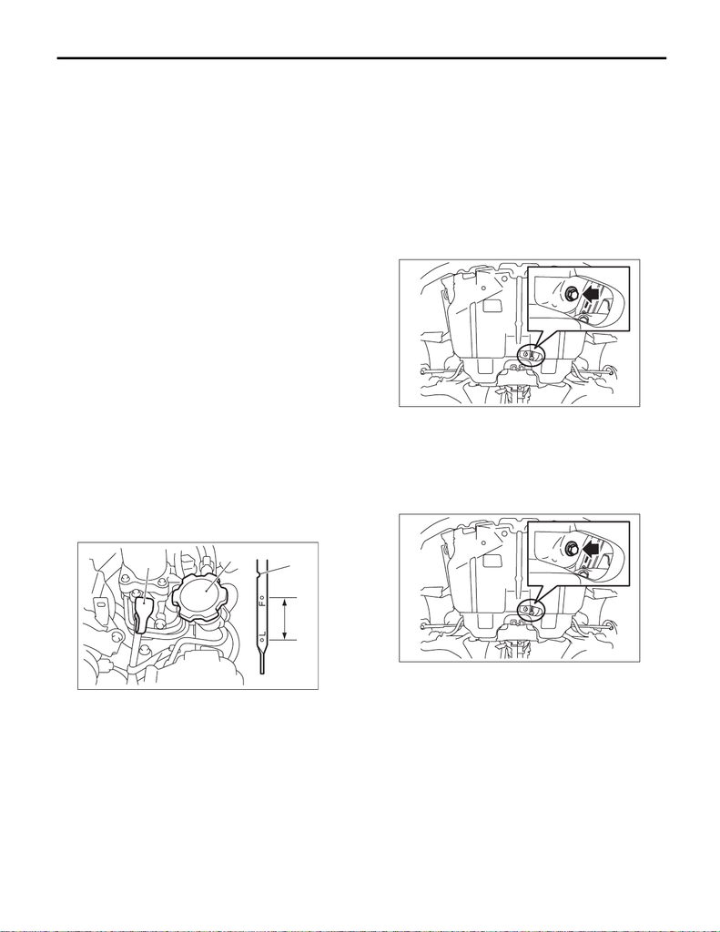

Engine Oil

LUBRICATION

3. Engine Oil

A: INSPECTION

CAUTION:

If the engine oil is spilt over exhaust pipe or the

under cover, wipe it off with cloth to avoid emis-

sion of smoke or causing a fire.

1) Park the vehicle on a level surface.

2) Remove the oil level gauge and wipe away the

oil.

3) Reinsert the oil level gauge all the way. Be sure

that the oil level gauge is correctly inserted and

properly orientated.

4) Pull out the oil level gauge again, and check the

oil level. If the engine oil level is below “L” line,

make sure that there is no oil leakage from the en-

gine, then add oil to raise the level up to the “F” line.

5) Start the engine, and spread the oil in engine

room.

6) After turning off the engine, wait a few minutes

for the oil to return to the oil pan before checking

the level.

NOTE:

• Just after driving or while the engine is warm, en-

gine oil level shows in the range between the “F”

line and the notch mark. This is caused by thermal

expansion of engine oil.

• To prevent overfilling of engine oil, do not add oil

above “F” line when the engine is cold.

• As the oil level gauge is used for daily mainte-

nance, “F” line and “L” line is set assuming that the

engine is cold.

B: REPLACEMENT

CAUTION:

If the engine oil is spilt over exhaust pipe or the

under cover, wipe it off with cloth to avoid emis-

sion of smoke or causing a fire.

1) Open the engine oil filler cap for quick draining of

engine oil.

2) Lift up the vehicle.

3) Drain engine oil by loosening the engine oil drain

plug.

NOTE:

Prepare the container for draining of engine oil.

4) Tighten the engine oil drain plug after draining

engine oil.

NOTE:

Use a new drain plug gasket.

Tightening torque:

46.5 N·m (4.7 kgf-m, 34.3 ft-lb)

5) Lower the vehicle.

6) Using engine oil of proper quality and viscosity,

fill engine oil through the filler duct to the “F” line on

the oil level gauge. Make sure that the vehicle is

parked on a level surface when checking oil level.

Recommended oil:

Refer to “SPECIFICATION” for recommended

oil. <Ref. to LU(STI)-2, SPECIFICATION, Gen-

eral Description.>

Engine oil capacity:

Refer to “SPECIFICATION” for engine oil ca-

pacity. <Ref. to LU(STI)-2, SPECIFICATION,

General Description.>

7) Close the engine oil filler cap.

(A) Oil level gauge

(B) Engine oil filler cap

(C) “F” line

(D) “L” line

(E) Approx. 1.0 L (1.1 US qt, 0.9 Imp qt)

(F) Notch mark

(F)

(B)

(A)

(E)

(D)

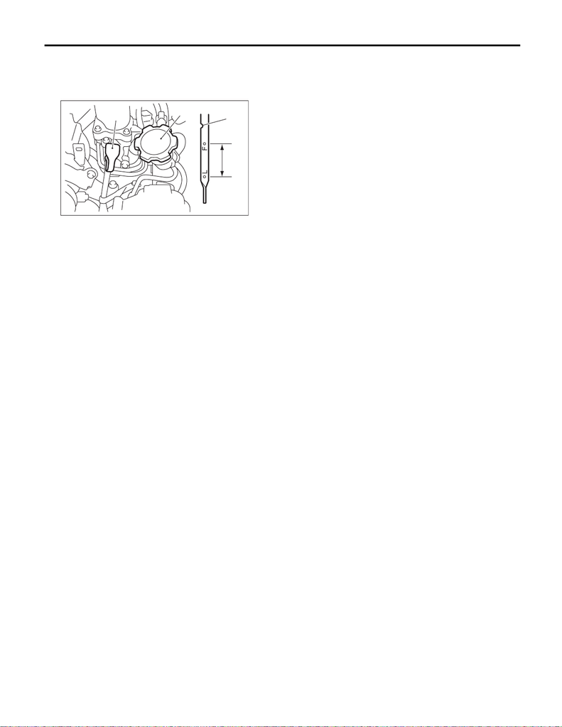

Engine Oil

LUBRICATION

8) Start the engine to circulate the oil in engine.

9) After stopping the engine, recheck the oil level. If

necessary, add engine oil up to the “F” line on oil

level gauge.

(A) Oil level gauge

(B) Engine oil filler cap

(C) “F” line

(D) “L” line

(E) Approx. 1.0 L (1.1 US qt, 0.9 Imp qt)

(F) Notch mark

(F)

(B)

(A)

(E)

(D)